# Estudio predictivo de enfermedades cardíacas

## **Pruebas de Hipótesis**

### **PRUEBA DE HIPOTESIS 1:**

Una presion arterial en reposo mayor a 80 mm Hg podría indicar hipertensión.Teniendo en cuenta esto, se plantea la siguiente hipotesis:

H0=Hipótesis nula

H1=Hipótesis complementaria

H0: El promedio de la presion arterial en reposo de mujeres es mayor o igual a 80mmHg X>=80

H0: µ >= 80

H1: El promedio de la presion arterial en reposo de mujeres menor a 80 mmHg x<80

H1: µ < 80

```r
n=193
alpha_2= 0.01
n_confianza=0.99
qt(alpha_2,n-1)#valor crítico=-2.345926
```

```
## [1] -2.345926
```

```r
x_r=mean(unlist(DF[DF$Sexo=="F",4]))#media de las mujeres con presion art
u=80
s=sd(unlist(DF[DF$Sexo=="F",4]))
t=(x_r-u)/(s*n^0.5)
t#0.1938021
```

```
## [1] 0.1938021
```

Se puede apreciar que el estadístico de prueba cae en la region de no rechazo de H0, Por lo tanto, no rechazamos H0 y no se rechaza decir que el promedio de la presion arterial en reposo de mujeres es mayor a 80mmHg.

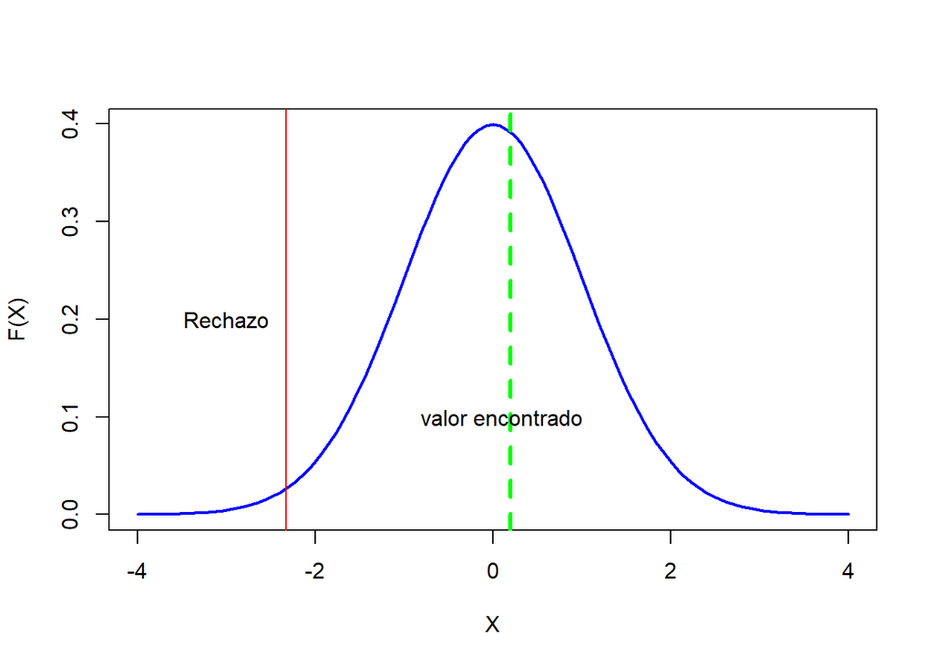

```r
presion_arterial_mujeres <- DF[DF$Sexo=="F",4]
x <- presion_arterial_mujeres
curve(dnorm(x),-4,4, col = "blue", lwd= 2, xlab = "X", ylab = "F(X)")
abline(v = qnorm(alpha_2),col = "Red")
abline(v = t, col = "green", lwd=3, lty=2)
text(-3,0.2,"Rechazo", col = "Black")
text(0.1,0.1,"valor encontrado", col = "black")
```

Se puede apreciar que el estadístico de prueba cae en la region de no rechazo de H0, por lo tanto, no rechazamos H0. Por lo que se podría decir que el promedio de la presion arterial en reposo de mujeres es mayor a 80mmHg

### **PRUEBA DE HIPOTESIS 2:**

H0=Hipótesis nula

H1=Hipótesis complementaria H0 = El promedio de la frecuencia cardiaca máxima alcanzada de mujeres es igual a 226

mu=226

H1 = El promedio de la frecuencia cardiaca máxima alcanzada de mujeres es diferente de 226 mu<226 o mu>226

Se tendrán 2 regiones de rechazo de H0 con un area de 0.025 cada uno (Prueba de hipótesis de 2 colas)

t= estadístico de prueba

```r
n=193
alpha_2=0.025
n_confianza=0.95
qnorm(alpha_2)#-1.959964
```

```
## [1] -1.959964
```

```r
x_r=mean(unlist(DF[DF$Sexo=="F",8]))#146.1399
u=226
s=sd(unlist(DF[DF$Sexo=="F",8]))#22.1549
t=(x_r-u)/(s*n^0.5)
t#-0.2594665
```

```
## [1] -0.2594665
```

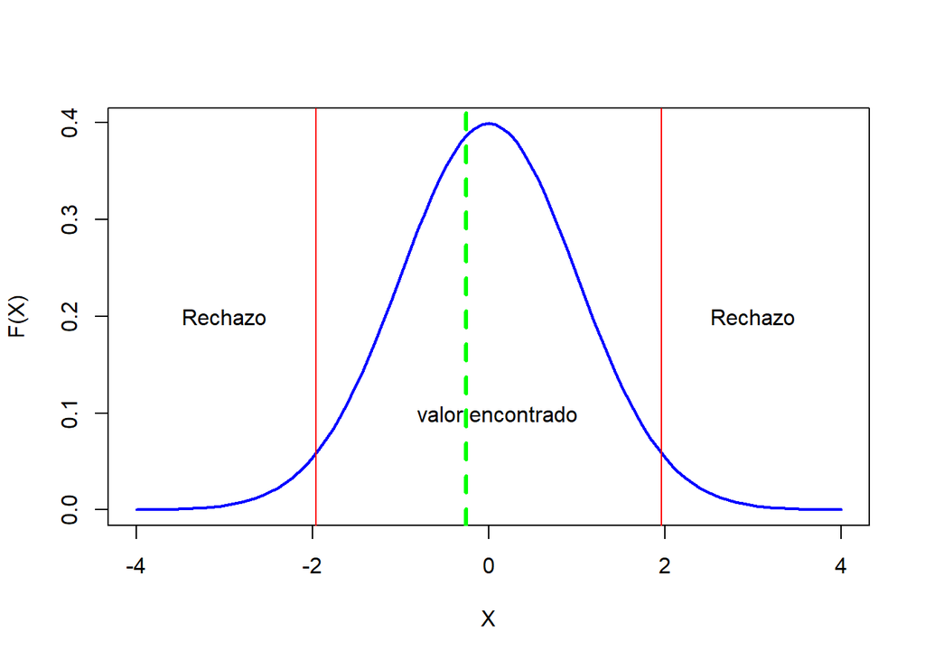

```r
f <- DF[DF$Sexo=="F",8]
x <- f
curve(dnorm(x),-4,4, col = "blue", lwd= 2, xlab = "X", ylab = "F(X)")
abline(v = qnorm(alpha_2),col = "Red")
abline(v = -qnorm(alpha_2),col = "Red")
abline(v = t, col = "green", lwd=3, lty=2)
text(-3,0.2,"Rechazo", col = "Black")
text(3,0.2,"Rechazo", col = "Black")
text(0.1,0.1,"valor encontrado", col = "black")
```

### **PRUEBA DE HIPOTESIS 3:**

H0=Hipótesis nula

H1=Hipótesis complementaria

H0 =El promedio de los hombres no presentan colesterolemia, teniendo en cuenta que una persona no presenta colesterolemia si su colesterol sérico es menor o igual a 200 mm/dl x<=200 mu<=200

H1 = El promedio de los hombres presentan colesterolemia x>200

Se tendrá una región de rechazo de H0 con un area de 0.01 (Prueba de hipótesis de una cola)

```r
n = 725
alpha_2 = 0.01
n_confianza = 0.99
valor_critico = qnorm(alpha_2) # valor crítico=  -2.326348

x_r = mean(unlist(DF[DF$Sexo=="M",5])) #media de los hombres con colesterol
s = sd(unlist(DF[DF$Sexo=="M",5])) # 112.3514
u = 200
t = (x_r-u)/(s*n^0.5)
t #-0.004127688
```

```
## [1] -0.004127688
```

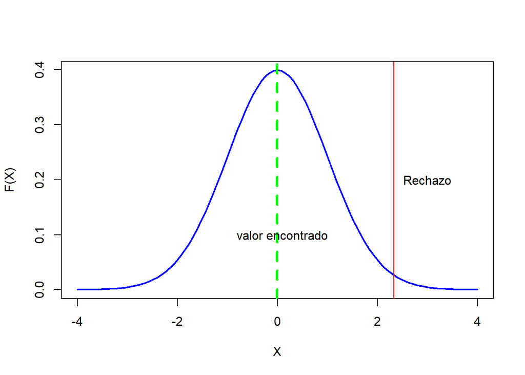

```r
f <- DF[DF$Sexo=="M",5]
x <- f
curve(dnorm(x),-4,4, col = "blue", lwd= 2, xlab = "X", ylab = "F(X)")
abline(v = -qnorm(alpha_2),col = "Red")
abline(v = t, col = "green", lwd=3, lty=2)
text(3,0.2,"Rechazo", col = "Black")

text(0.1,0.1,"valor encontrado", col = "black")
```

Se puede apreciar que el estadístico de prueba cae en la zona de no rechazo de H0. Por lo tanto, no se puede rechazar H0 y no se puede descartar que en promedio, los hombres no presentan colesterolemia

#### —————————————————————————————————–

## **Regresiones y predicciones**

### **REGRESIÓN 1**

A continuación se realizará la regresión para explicar el comportamiento de la variable Frecuencia cardíaca máxima alcanzada en función de la edad.

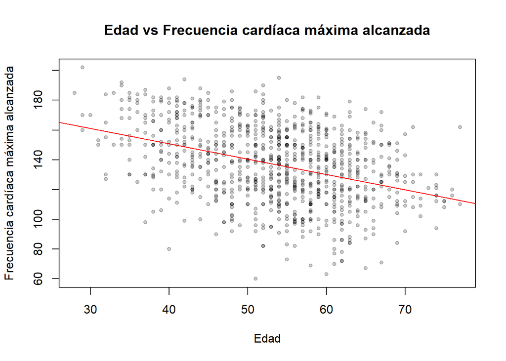

```r
lma<-lm(DF$FrecuenciaCardiacaMaximaAlcanzada ~ DF$Edad)

plot(DF$Edad,DF$FrecuenciaCardiacaMaximaAlcanzada, pch=20, main = "Edad vs Frecuencia cardíaca máxima alcanzada", xlab="Edad", ylab = "Frecuencia cardíaca máxima alcanzada",col=rgb(0,0,0,0.2))
abline(lma,col="red")
```

### *Ahora analizamos si efectivamente existe una correlacion lineal*

```r
cor.test(DF$FrecuenciaCardiacaMaximaAlcanzada,DF$Edad)
```

```
##
##  Pearson's product-moment correlation
##
## data:  DF$FrecuenciaCardiacaMaximaAlcanzada and DF$Edad
## t = -12.512, df = 916, p-value < 2.2e-16
## alternative hypothesis: true correlation is not equal to 0
## 95 percent confidence interval:
##  -0.4359714 -0.3253842
## sample estimates:
##        cor
## -0.3820447
```

Al analizar el coeficiente de correlación de Pearson nos damos cuenta que sí existe una correlación lineal entre estas dos varibles y que la fuerza de esta correlación inversa es media.

Tras observar podemos darnos cuenta que existe una tendencia que se modela mediante una pendiente negativa en el comportamiento de la variable Frecuencia cardíaca máxima alcanzada respecto a la edad. Luego de ese analisis podemos plantear la siguiente hipótesis: A medida que la edad aumenta, la Frecuencia cardíaca máxima alcanzada disminuye. Sin embargo, para validar lo planteado se analizará el resumen de regresión.

### *Resumen de regresión*

```r
summary(lma)
```

```
##
## Call:
## lm(formula = DF$FrecuenciaCardiacaMaximaAlcanzada ~ DF$Edad)
##
## Residuals:
##     Min      1Q  Median      3Q     Max
## -79.399 -15.922   0.726  18.196  58.695
##
## Coefficients:
##              Estimate Std. Error t value Pr(>|t|)
## (Intercept) 191.99020    4.47820   42.87   <2e-16 ***
## DF$Edad      -1.03121    0.08242  -12.51   <2e-16 ***
## ---
## Signif. codes:  0 '***' 0.001 '**' 0.01 '*' 0.05 '.' 0.1 ' ' 1
##
## Residual standard error: 23.54 on 916 degrees of freedom
## Multiple R-squared:  0.146,  Adjusted R-squared:  0.145
## F-statistic: 156.5 on 1 and 916 DF,  p-value: < 2.2e-16
```

Como primer punto en este análisis, debemos verificar que los residuos siguen el modelo normal:

La media de los residuos es:

```r
mean(lma$residuals)
```

```
## [1] 1.187184e-15
```

El histograma de los residuos es:

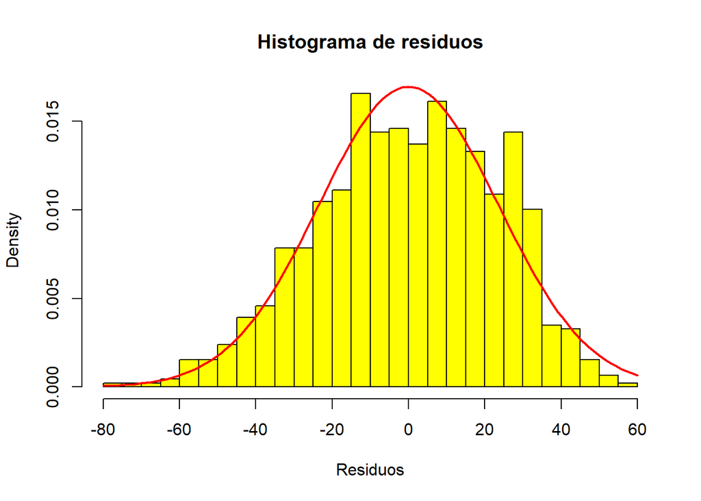

```r
hist(lma$residuals, breaks= 20,main="Histograma de residuos", col="yellow", xlab = "Residuos", freq = FALSE)
curve(dnorm(x, mean(lma$residuals), sd = sd(lma$residuals)),
      col = "Red",
      lwd= 2,
      las = 1,
      ann = FALSE,
      xaxp = c(-15, 15, 5),
      ylim = c(0,0.00020),
      yaxs = "i", add=TRUE)
```

Despues de observar este grafico se puede diferir que los residuos siguen una distribución cercana a la normal. Así mismo, su media es aproximadamente 0, esto aseguraria que el modelo presenta una linealidad.

A partir del resumen se obtienen las siguientes observaciones:

Con respecto al p−value del los coeficientes:

Intercepto: Para una significancia de 0.01 la hipótesis nula (H0) puesto que el p-values es menor a la significancia. Por lo tanto, (H0) se rechaza por lo que el valor de b≠0

Pendiente: Para una significancia de 0.01 la hipótesis nula (H0) puesto que el p-values es menor a la significancia. Por lo tanto, (H0) se rechaza por lo que el valor de a≠0

Con respecto la r cuadrado ajustado:

La variabilidad de la variable Frecuencia Cardiaca máxima alcanzada se explica solamente en un 14.5 % a través de la variación de la variable Edad. Este bajo porcentaje sugiere que ademas de esta variable existen otras que influyen en la variación de la Frecuencia cardíaca máxima alcanzada.

Con respecto al p−value del modelo:

Dado que el p−value (2.2e-16) es menor que la significancia (α=0.01) se rechaza la hipótesis nula H0 por lo que se sugiere que el modelo es valido.

### *Gráficas de Diagnóstico*

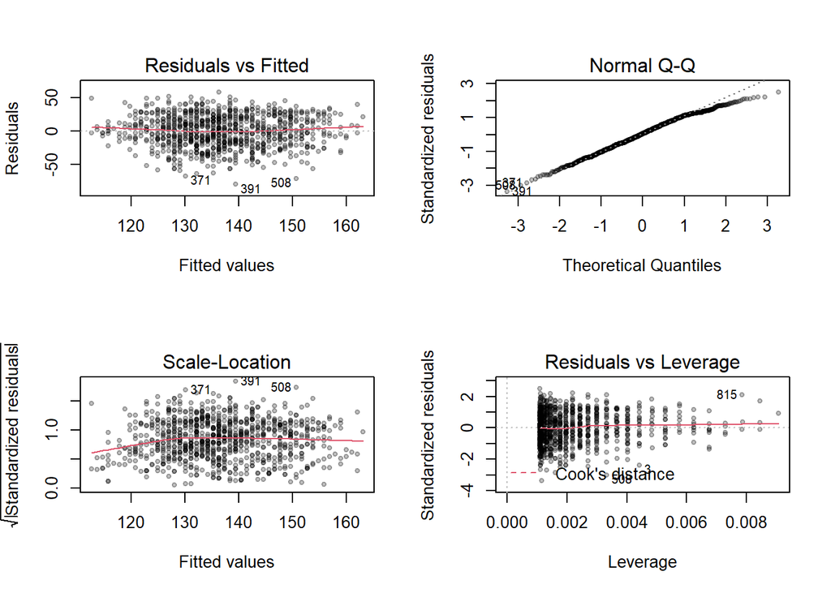

```r
op=par(mfrow=c(2,2))
plot(lma, pch=20,col=rgb(0,0,0,0.25))
```

Luego de observar gráficas de diagnóstico de la línea de ajuste, se tienen las siguientes observaciones:

En la gráfica de Residuos vs. Valores ajustados:

-> Tenemos 3 valores atípicos.

-> Puede observarse que existen residuos positivos y negativos alrededor de la línea roja.

-> Los residuos son homocedásticos ya que no se distribuyen uniformemente alrededor de la línea roja.

En la gráfica de la Normal Q-Q:

-> Puede observarse que que la forma de la gráfica tiene una tendencia a la linealidad y se ajusta a la línea normal. llendo de esto podemos decir que el modelo puede ser adecuado.

En la gráfica Scale Location:

-> Los residuos están distribuidos alrededor de la recta roja y la misma es aproximadamente plana. Por lo que a partir de esta información se refuerza la condición de homocedasticidad del modelo.

Con respecto a la gráfica Residual vs. Leverage:

-> Puede observarse en la grafica que existen algunos puntos que producen el efecto palanca, Aquellos podrían ser determinantes de la tendencia.

#### **Ahora se usara el modelo para hacer predicciones**

De acuerdo a los resultados analizados, nuestro modelo resulta significativo y se ajusta a la siguiente expresión:

```r
lma$coefficients
```

```
## (Intercept)     DF$Edad
##  191.990204   -1.031208
```

Intercepto = 191.99 pendiente = -1.03

y = 191.99 + (-1.03x)

Frecuencia cardíaca máxima alcanzada = -1.03(Edad) + 191.99

Para corroborar el ajuste, haremos una predicción para de la frecuencia cardíaca maxima alcanzada en las personas con 60 años de edad y corroboraremos el modelo comparandolo con el promedio de la frecuencia cardíaca máxima alcanzada de las personas con 60 años de edad de la data utilizada.

Evaluando:

Frecuencia cardíaca máxima alcanzada = -1.03 * (60) + 191.99 Frecuencia cardíaca máxima alcanzada = 130.19

Ahora, para verificar si nuestro modelo resulto ser útil o no, se calculará el promedio de la frecuencia cardíaca máxima alcanzada de las personas con 60 años de edad real a partir de la base datos.

```r
promedio_F = DF %>% filter(grepl("60",Edad)) %>% pull(FrecuenciaCardiacaMaximaAlcanzada) %>% mean()
promedio_F
```

```
## [1] 135.25
```

Luego de estas observaciones podemos darnos cuenta que nuestros valores difieren:

Valorestimado ≠ Valorreal 130.19 ≠ 135.25

ahora, teniendo los valores teóricos y valores estimados se calculará el porcentaje de error.

% error = |((Valorteórico−Valorestimado) / Valorteórico) x 100% | % error=|((135.25 - 130.19)/ 135.25 ) * 100 % | % error= 3.74 %

Se observa que el porcentanje de error es cercano al 3.74 %. Por lo que, se puede decir que nuestra regresión es significativa y pero, no al ofrece una conclusión efectiva al 100% frente a las predicciones, ya que para determinar la frecuencia cardíaca máxima alcanzada depende de otros factores.

### **REGRESIÓN 2**

A continuación se realizará la regresión para explicar el comportamiento de la variable presión arterial en reposo en función de la edad.

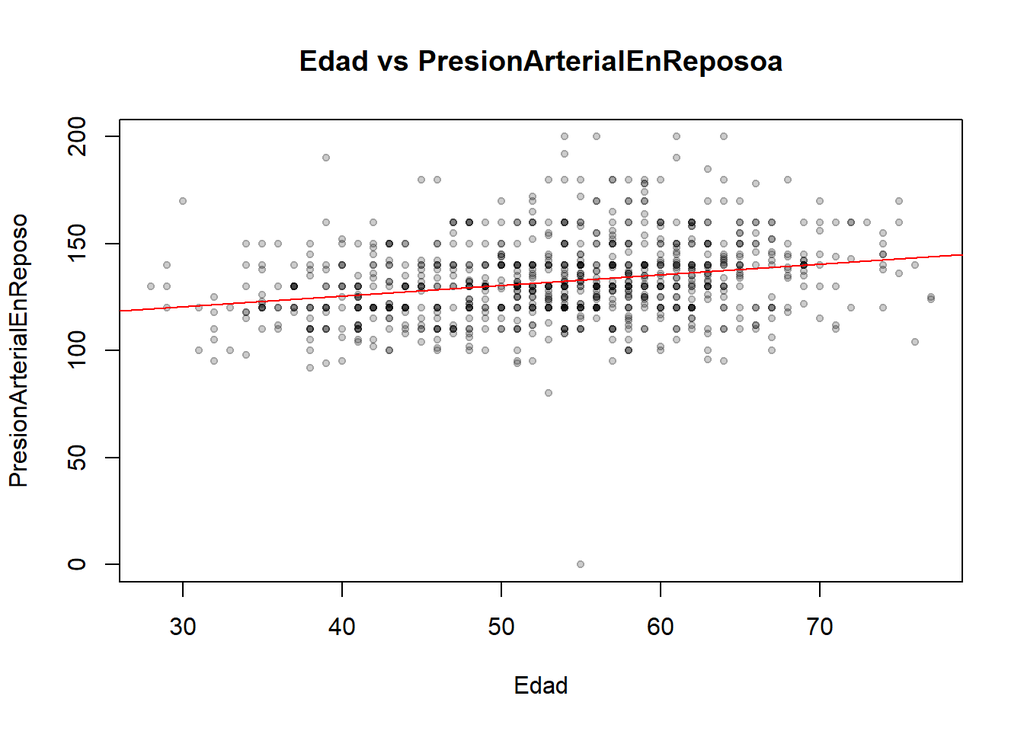

```r
lmb<-lm(DF$PresionArterialEnReposo ~ DF$Edad)


plot(DF$Edad,DF$PresionArterialEnReposo, pch=20, main = "Edad vs PresionArterialEnReposoa", xlab="Edad", ylab = "PresionArterialEnReposo",col=rgb(0,0,0,0.2))
  abline(lmb,col="red")
```

### *Ahora analizamos si efectivamente existe una correlacion lineal*

```r
cor.test(DF$PresionArterialEnReposo,DF$Edad)
```

```
##
##  Pearson's product-moment correlation
##
## data:  DF$PresionArterialEnReposo and DF$Edad
## t = 7.9615, df = 916, p-value = 5.015e-15
## alternative hypothesis: true correlation is not equal to 0
## 95 percent confidence interval:
##  0.1928702 0.3139357
## sample estimates:
##       cor
## 0.2543994
```

Al analizar el coeficiente de correlación de Pearson nos damos cuenta que sí existe una correlación lineal entre estas dos varibles. Sin embargo, la fuerza de esta correlación directa es baja.

Tras observar podemos darnos cuenta que existe una tendencia que se modela mediante una pendiente postiva en el comportamiento de la variable Presión arterial en reposo respecto a la edad. Luego de ese análisis podemos plantear la siguiente hipótesis: A medida que la edad aumenta, la Presión arterial en reposo tambien aumenta. Sin embargo, para validar lo planteado se analizará el resumen de regresión.

### *Resumen de regresión*

```r
summary(lmb)
```

```
##
## Call:
## lm(formula = DF$PresionArterialEnReposo ~ DF$Edad)
##
## Residuals:
##      Min       1Q   Median       3Q      Max
## -133.140  -11.143   -1.151    9.357   67.359
##
## Coefficients:
##              Estimate Std. Error t value Pr(>|t|)
## (Intercept) 105.67692    3.40781  31.010  < 2e-16 ***
## DF$Edad       0.49933    0.06272   7.961 5.01e-15 ***
## ---
## Signif. codes:  0 '***' 0.001 '**' 0.01 '*' 0.05 '.' 0.1 ' ' 1
##
## Residual standard error: 17.91 on 916 degrees of freedom
## Multiple R-squared:  0.06472,    Adjusted R-squared:  0.0637
## F-statistic: 63.38 on 1 and 916 DF,  p-value: 5.015e-15
```

Como primer punto en este análisis, debemos verificar que los residuos siguen el modelo normal:

La media de los residuos es:

```r
mean(lmb$residuals)
```

```
## [1] -1.465719e-15
```

El histograma de los residuos es:

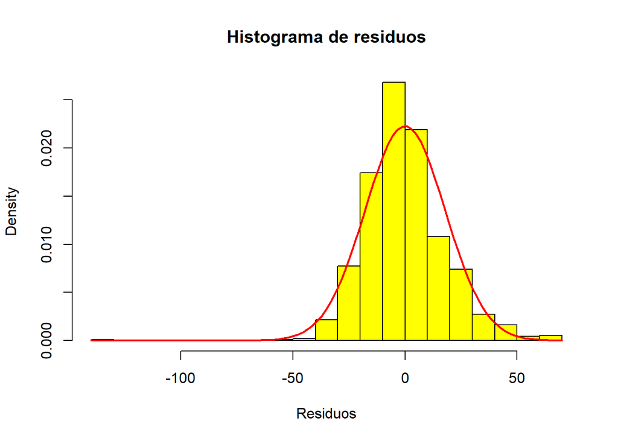

```r
hist(lmb$residuals, breaks= 20,main="Histograma de residuos", col="Yellow", xlab = "Residuos", freq = FALSE)
curve(dnorm(x, mean(lmb$residuals), sd = sd(lmb$residuals)),
      col = "Red",
      lwd= 2,
      las = 1,
      ann = FALSE,
      xaxp = c(-15, 15, 5),
      ylim = c(0,0.00020),
      yaxs = "i", add=TRUE)
```

Despues de observar este grafico se puede diferir que los residuos siguen una distribución cercana a la normal. Así mismo, su media es aproximadamente 0, esto aseguraria que el modelo presenta una linealidad.

A partir del resumen se obtienen las siguientes observaciones:

Con respecto al p−value del los coeficientes:

Intercepto: Para una significancia de 0.01 la hipótesis nula (H0) puesto que el p-values es menor a la significancia. Por lo tanto, (H0) se rechaza por lo que el valor de b≠0

Pendiente: Para una significancia de 0.01 la hipótesis nula (H0) puesto que el p-values es menor a la significancia. Por lo tanto, (H0) se rechaza por lo que el valor de a≠0

Con respecto la r cuadrado ajustado:

La variabilidad de la variable Presión arterial en reposo se explica solamente en un 6.37 % a través de la variación de la variable Edad. Este bajo porcentaje sugiere que ademas de esta variable existen otras que influyen en la variación de la Presión arterial en reposo .

Con respecto al p−value del modelo:

Dado que el p−value (5.015e-15) es menor que la significancia (α=0.01) se rechaza la hipótesis nula H0 por lo que se sugiere que el modelo es valido.

### *Gráficas de Diagnóstico*

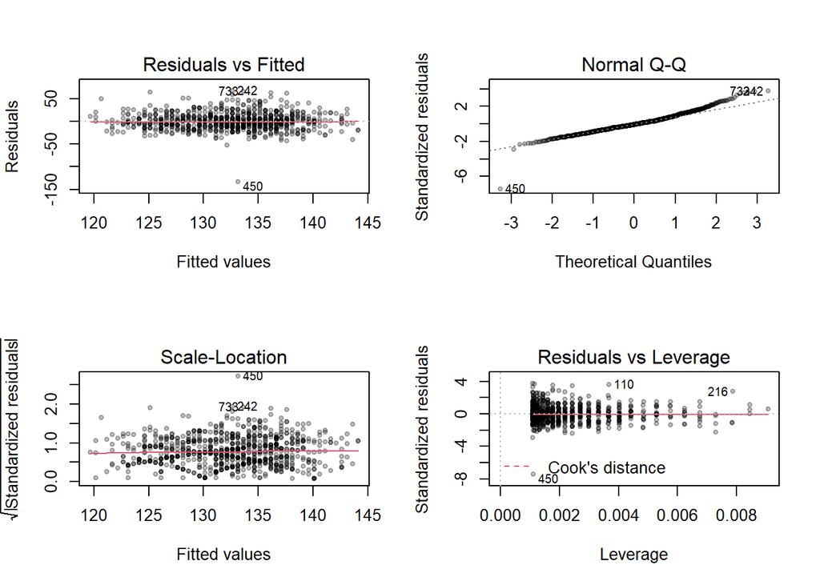

```r
op=par(mfrow=c(2,2))
plot(lmb, pch=20,col=rgb(0,0,0,0.25))
```

Luego de observar gráficas de diagnóstico de la línea de ajuste, se tienen las siguientes observaciones:

En la gráfica de Residuos vs. Valores ajustados:

-> Tenemos 3 valores atípicos.

-> Puede observarse que existen residuos positivos y negativos alrededor de la línea roja.

-> Los residuos son homocedásticos ya que no se distribuyen uniformemente alrededor de la línea roja.

En la gráfica de la Normal Q-Q:

-> Puede observarse que algunos valores no se ajustan a la linea normal

-> Puede observarse que que la forma de la gráfica tiene una tendencia a la linealidad y se ajusta en su mayoria a la línea normal. llendo de esto podemos decir que el modelo puede ser adecuado.

En la gráfica Scale Location:

-> Los residuos están distribuidos alrededor de la recta roja y la misma es aproximadamente plana. Por lo que a partir de esta información se refuerza la condición de homocedasticidad del modelo.

### **Ahora se usara el modelo para hacer predicciones**

De acuerdo a los resultados analizados, nuestro modelo resulta significativo y se ajusta a la siguiente expresión:

```r
lmb$coefficients
```

```
## (Intercept)     DF$Edad
## 105.6769171   0.4993301
```

Intercepto = 105.677 pendiente = 0.499

y = 105.677 + (0.499x)

Presión Arterial en reposo = 0.499(Edad) + 105.677

Para corroborar el ajuste, haremos una predicción para de la Presión Arterial en reposo en las personas con 50 años de edad y corroboraremos el modelo comparandolo con el promedio de la Presión Arterial en reposo de las personas con 50 años de edad de la data utilizada.

Evaluando:

Presión Arterial en reposo = 0.499*(50) + 105.677

Presión Arterial en reposo = 130.627

Ahora, para verificar si nuestro modelo resulto ser útil o no, se calculará el promedio de la Presión Arterial en reposo de las personas con 50 años de edad real a partir de la base datos.

```r
promedio_P = DF %>% filter(grepl("50",Edad)) %>% pull(PresionArterialEnReposo) %>% mean()
promedio_P
```

```
## [1] 135
```

Luego de estas observaciones podemos darnos cuenta que nuestros valores difieren:

Valorestimado ≠ Valorreal 130.627 ≠ 135

ahora, teniendo los valores teóricos y valores estimados se calculará el porcentaje de error.

Se observa que el porcentanje de error es cercano al 3.24 %. Por lo que, se puede decir que nuestra regresión es significativa y pero, no ofrece una conclusión efectiva al 100% frente a las predicciones, ya que para determinar la Presión arterial en resposo depende de otros factores.

### **REGRESIÓN 3**

A continuación se realizará la regresión para explicar el comportamiento de la variable Colesterol Sérico en función de la edad.

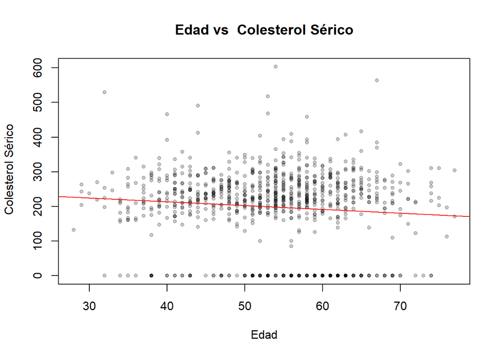

```r
lmc<-lm(DF$ColesterolSerico ~ DF$Edad)

plot(DF$Edad,DF$ColesterolSerico, pch=20, main = "Edad vs  Colesterol Sérico", xlab="Edad", ylab = " Colesterol Sérico",col=rgb(0,0,0,0.2))
abline(lmc,col="red")
```

### *Ahora analizamos si efectivamente existe una correlacion lineal*

```r
cor.test(DF$ColesterolSerico,DF$Edad)
```

```
##
##  Pearson's product-moment correlation
##
## data:  DF$ColesterolSerico and DF$Edad
## t = -2.8969, df = 916, p-value = 0.003858
## alternative hypothesis: true correlation is not equal to 0
## 95 percent confidence interval:
##  -0.15900537 -0.03076757
## sample estimates:
##         cor
## -0.09528177
```

Al analizar el coeficiente de correlación de Pearson nos damos cuenta que sí existe una correlación lineal entre estas dos varibles y que la fuerza de esta correlación inversa es baja.

Tras observar podemos darnos cuenta que existe una tendencia que se modela mediante una pendiente negativa en el comportamiento de la variable Colesterol Sérico respecto a la edad. Luego de ese analisis podemos plantear la siguiente hipótesis: A medida que la edad aumenta, el Colesterol Sérico disminuye. Sin embargo, para validar lo planteado se analizará el resumen de regresión.

### *Resumen de regresión*

```r
summary(lmc)
```

```
##
## Call:
## lm(formula = DF$ColesterolSerico ~ DF$Edad)
##
## Residuals:
##     Min      1Q  Median      3Q     Max
## -222.57  -27.73   24.45   68.41  404.74
##
## Coefficients:
##             Estimate Std. Error t value Pr(>|t|)
## (Intercept) 257.9250    20.7240  12.446  < 2e-16 ***
## DF$Edad      -1.1049     0.3814  -2.897  0.00386 **
## ---
## Signif. codes:  0 '***' 0.001 '**' 0.01 '*' 0.05 '.' 0.1 ' ' 1
##
## Residual standard error: 108.9 on 916 degrees of freedom
## Multiple R-squared:  0.009079,   Adjusted R-squared:  0.007997
## F-statistic: 8.392 on 1 and 916 DF,  p-value: 0.003858
```

Como primer punto en este análisis, debemos verificar que los residuos siguen el modelo normal:

La media de los residuos es:

```r
mean(lmc$residuals)
```

```
## [1] 1.723732e-14
```

El histograma de los residuos es:

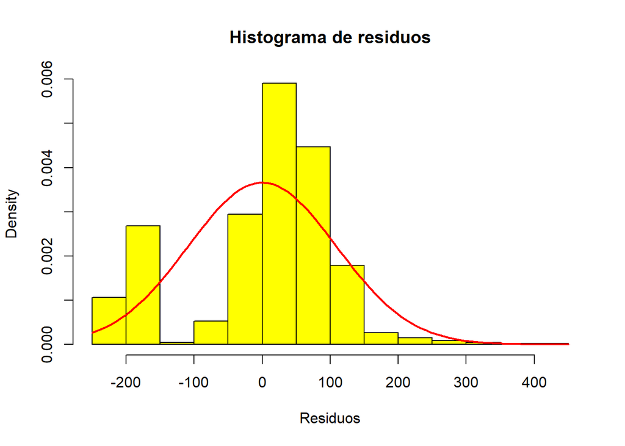

```r
hist(lmc$residuals, breaks= 20,main="Histograma de residuos", col="yellow", xlab = "Residuos", freq = FALSE)
curve(dnorm(x, mean(lmc$residuals), sd = sd(lmc$residuals)),
      col = "Red",
      lwd= 2,
      las = 1,
      ann = FALSE,
      xaxp = c(-15, 15, 5),
      ylim = c(0,0.00020),
      yaxs = "i", add=TRUE)
```

A partir del resumen se obtienen las siguientes observaciones:

Con respecto al p−value del los coeficientes:

Intercepto: Para una significancia de 0.01 la hipótesis nula (H0) puesto que el p-values es menor a la significancia. Por lo tanto, (H0) se rechaza por lo que el valor de b≠0

Pendiente: Para una significancia de 0.01 la hipótesis nula (H0) puesto que el p-values es menor a la significancia. Por lo tanto, (H0) se rechaza por lo que el valor de a≠0

Con respecto la r cuadrado ajustado:

La variabilidad de la variable Colesterol Sérico se explica solamente en un 0.80 % a través de la variación de la variable Edad. Este bajo porcentaje sugiere que ademas de esta variable existen otras que influyen en la variación de la Colesterol Sérico.

Con respecto al p−value del modelo:

Dado que el p−value ( 0.003858) es menor que la significancia (α=0.01) se rechaza la hipótesis nula H0 por lo que se sugiere que el modelo es valido.

### *Gráficas de Diagnóstico*

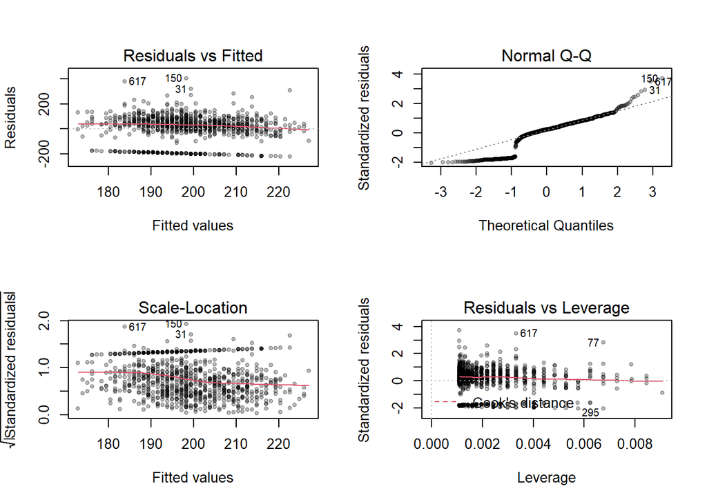

```r
op=par(mfrow=c(2,2))
plot(lmc, pch=20,col=rgb(0,0,0,0.25))
```

Luego de observar gráficas de diagnóstico de la línea de ajuste, se tienen las siguientes observaciones:

En la gráfica de Residuos vs. Valores ajustados:

-> Tenemos 3 valores atípicos.

-> Puede observarse que existen residuos positivos y negativos alrededor de la línea roja.

-> Los residuos son homocedásticos ya que no se distribuyen uniformemente alrededor de la línea roja a excepción de algunos valores.

Con respecto a la gráfica Residual vs. Leverage:

-> Puede observarse en la grafica que existen algunos puntos que producen el efecto palanca, Aquellos podrían ser determinantes de la tendencia.

#### **Ahora se usara el modelo para hacer predicciones**

De acuerdo a los resultados analizados, nuestro modelo resulta significativo y se ajusta a la siguiente expresión:

```r
lmc$coefficients
```

```
## (Intercept)     DF$Edad
##  257.924982   -1.104923
```

Intercepto = 257.92 pendiente = -1.10

y = 257.92 + (-1.10x)

Colesterol Sérico = -1.10(Edad) + 257.92

Para corroborar el ajuste, haremos una predicción para del Colesterol Sérico en las personas con 40 años de edad y corroboraremos el modelo comparandolo con el promedio de la Colesterol Sérico de las personas con 40 años de edad de la data utilizada.

Evaluando:

Colesterol Sérico = -1.10 * (40) + 257.92 Colesterol Sérico = 213.92

Ahora, para verificar si nuestro modelo resulto ser útil o no, se calculará el promedio de la Colesterol Sérico de las personas con 40 años de edad real a partir de la base datos.

```r
promedio_C= DF %>% filter(grepl("40",Edad)) %>% pull(ColesterolSerico) %>% mean()
promedio_C
```

```
## [1] 229.3846
```

Luego de estas observaciones podemos darnos cuenta que nuestros valores difieren:

Valorestimado ≠ Valorreal 213.92 ≠ 229.38

ahora, teniendo los valores teóricos y valores estimados se calculará el porcentaje de error.

% error = |((Valorteórico−Valorestimado) / Valorteórico) x 100% | % error=|((229.38 - 213.92)/ 229.38 ) * 100 % | % error= 6.74 %

Se observa que el porcentanje de error es cercano al 6.74 %. Por lo que, se puede decir que nuestra regresión es significativa, pero, no ofrece una conclusión efectiva al 100% frente a las predicciones, ya que el determinar el colesterol sérico de las personas depende de otros factores.

## **Fuentes**

Base de datos: [Kaggle - Heart disease Database](https://www.kaggle.com/fedesoriano/heart-failure-prediction)

[^1]: https://www.sanofi.com.pe/es/media/80-por-ciento-de-los-fallecimientos-por-enfermedades-cardiovasculares-son-prevenibles
[^2]: https://medlineplus.gov/spanish/cholesterollevelswhatyouneedtoknow.html
[^3]: https://www.gob.pe/institucion/minsa/campa%C3%B1as/361-mide-tu-presion-y-ayuda-a-tu-corazon